# MoveTraits.V0.1 Spatial Annotation Tutorial

Anne G. Hertel

8/20/2026

```r
library(tidyverse);library(bit64); library(geodata);library(dggridR);library(terra); library(sf); library(mapview);library(RColorBrewer);library(dplyr);library(stringr);library(purrr);library(ggspatial)
```

# **Download the database**

https://doi.org/10.6084/m9.figshare.28611890.v2

# **Load MoveTraits database**

The database has four levels, stored in separate files: + species level trait summaries + individual level traits summaries + individual monthly trait summaries + within individual repeated trait measures.

# **Defining the spatial grid**

We have annotated traits with spatial grids to facilitate annotation with environmental layers while protecting the underlying gps coordinates. We are using hexagonal equal area grids from the the dggridR package at approximately 1 square kilometer (1km resolution), 100 square kilometer (10km resolution) and 10000 square kilometer (100km resolution).

In order to link the grid cell identities provided in the database back to a spatial representation we have to define the three spatial grids as follows:

```r
dggs.100    <- dgconstruct(projection = "ISEA", area = 10000, resround='nearest')
```

```
## Resolution: 8, Area (km^2): 7774.20548276313, Spacing (km): 87.0821287828498, CLS (km): 99.4910857271796
```

```r
dggs.10     <- dgconstruct(projection = "ISEA", area = 100, resround='nearest')
```

```
## Resolution: 12, Area (km^2): 95.9778454662114, Spacing (km): 9.67579208698331, CLS (km): 11.0545373458563
```

```r
dggs.1      <- dgconstruct(projection = "ISEA", area = 1, resround='nearest')
```

```
## Resolution: 16, Area (km^2): 1.18491167242236, Spacing (km): 1.07508800966481, CLS (km): 1.22828188927244
```

As an example for how the grid looks like - we are here showing exemplary the grid cells at 100km resolution (10000 square km) intersecting Germany.

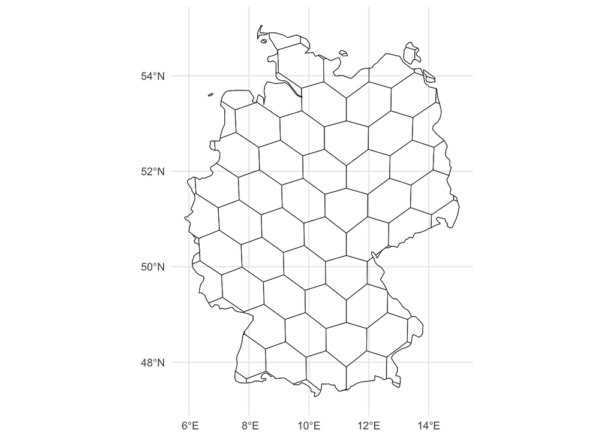

# **Species level**

We load the species level database which contains one row per species with trait summaries and information of all occupied grid cells where the species was observed ad where the traits where measured.

```r
mt_sp <- readRDS("MoveTrait.v0.1_species.sum_20260807.rds")
```

Spatial annotations are stored in the columns **grid.id.100km** and **grid.id.10km**.

```r
colnames(mt_sp)
```

```
##  [1] "species"              "common_name"          "n.ind"
##  [4] "class"                "movement.mode"        "grid.id.100km"
##  [7] "grid.id.10km"         "contact_person_name"  "d1h_species_mean"
## [10] "d24h_species_mean"    "dmax24h_species_mean" "dmax1m_species_mean"
## [13] "dmax12m_species_mean" "mcp24h_species_mean"  "mcp1m_species_mean"
## [16] "mcp12m_species_mean"  "iou24h_species_mean"  "iou1m_species_mean"
## [19] "iou12m_species_mean"  "di_species_mean"      "d1h_species_cv"
## [22] "d24h_species_cv"      "dmax24h_species_cv"   "dmax1m_species_cv"
## [25] "dmax12m_species_cv"   "mcp24h_species_cv"    "mcp1m_species_cv"
## [28] "mcp12m_species_cv"    "iou24h_species_cv"    "iou1m_species_cv"
## [31] "iou12m_species_cv"    "di_species_cv"        "d1h_species_n"
## [34] "d24h_species_n"       "dmax24h_species_n"    "dmax1m_species_n"
## [37] "dmax12m_species_n"    "mcp24h_species_n"     "mcp1m_species_n"
## [40] "mcp12m_species_n"     "iou24h_species_n"     "iou1m_species_n"
## [43] "iou12m_species_n"     "di_species_n"
```

For each species, all occupied cells are listed, separated by a semicolon.

```r
str(mt_sp$grid.id.100km)
```

```
##  chr [1:254] "2977;3058;2976;2975;3139;3140;2895;3057;2896;2814;2815;2894;3220;2813;2897;3221;3643;3562;3561;2893;1836;1837;1"| __truncated__ ...
```

We can select a species and visualize the occupied grid cells. For example the white stork “Ciconia ciconia”

```r
focal_species <- "Ciconia ciconia"

grid.id.100km <- mt_sp |>
  filter(species == focal_species) |>
  pull(grid.id.100km) |>
  strsplit(";") |>
  unlist() |>
  as.numeric()
```

Where did the species occur? Maps are dynamic and you can zoom in and explore.

```r
intersect_cells_100 <- dgcellstogrid(dggs.100, grid.id.100km)
mapview(intersect_cells_100, map.types = c("OpenStreetMap.DE"), col.regions = "#CC5500", legend = FALSE)
```

[interactive chart not shown]

We can do the same for the finer 10 km grid cells. Here for example for Fishers.

```r
focal_species <- "Martes pennanti"

grid.id.10km <- mt_sp |>
  filter(species == focal_species) |>
  pull(grid.id.10km) |>
  strsplit(";") |>
  unlist() |>
  as.numeric()

intersect_cells_10 <- dgcellstogrid(dggs.10, grid.id.10km)
mapview(intersect_cells_10, map.types = c("OpenStreetMap.DE"), col.regions = "#CC5500", legend = FALSE)
```

[interactive chart not shown]

In the remainder of the tutorial we will demonstrate grid cell annotation using three exemplary individuals, one stork, one fisher, and one lion. All functions work for every individual, provided the trait of interest could be calculated.

Please proceed to find out how grid cells can be annotated with the environment. Since traits are summarized for the species level of the database, individual grid cells can not be associated with a value of the trait expression.

# **Individual level**

The individual level database contains one row per individual with trait summaries and information of all by the individual occupied grid cells.

```r
mt_ind <- readRDS("MoveTrait.v0.1_individual.sum_20260807.rds")
```

The individual level database follows the same structure as the species level database. But contains more individual level information, such as the study and individual id:

Column descriptions

| ColumnName | Explanation |
| --- | --- |
| study_id | Movebank study identifier |
| individual_id | Movebank individual identifier |
| individual_local_identifier | Individual identifier given by the data owner |
| species | Species latin name |
| common_name | Speceis common name |
| class | Taxonomic class (mammal/bird) |
| movement.mode | Primary movement mode (walk, fly, swim) |
| sex | Female / male |
| animal_mass | Mass in gram |
| animal_life_stage | Life stage when tag was deployed |
| source | Movebank or Tucker et al. |
| grid.id.100km | Intersecting 100km grid cell identities |
| grid.id.10km | Intersecting 10km grid cell identities |

## From cell identity to spatial annotation

We select a focal individual and unpack it’s gridded information

```r
focal_individual <- "10666985"

grid.id.100km <- mt_ind |>
  filter(individual_id == focal_individual) |>
  pull(grid.id.100km) |>
  strsplit(";") |>
  unlist() |>
  as.numeric()
```

```
##  [1] 20894 20813 20812 20731 20730 20648 20566 20565 20483 20401 20319 20318
## [13] 20236 20235 20153 20152 20070 19988 19987 19905 19904 19822 19903 19902
## [25] 19983 19982 19981 20062 20061 20060 20141 20059 20140 20222 20221 20302
## [37] 20301 20300 20299 20218 20217 20135 20134 20053 20052 19970 19888 19806
## [49] 19805 19723 19722 16768 16767 16848 16929 17010 17009 17008 17089 17088
## [61] 17087 17086 17004 17003 17002 16920 16919 16918 16917 16835 16834 16833
## [73] 16751 16669 16668 16587 16586 16585 16504 16422 16503 16421 16339 16257
## [85] 16338 16420 16502
```

```
## [1] 87
```

The animal moved over 87 grid cells of 100km resolution (10000 square km). Therefore the trait summary is associated to that space.

Now we can use the *dgcellstogrid()* function to visualize where the individual occurred.

```r
intersect_cells_100 <- dgcellstogrid(dggs.100, grid.id.100km)
mapview(intersect_cells_100, map.types = c("OpenStreetMap.DE"), col.regions = "#CC5500", legend = FALSE)
```

[interactive chart not shown]

We can use the *dgSEQNUM_to_GEO()* function to get each grid cells centroid coordinates.

```r
lon <- dgSEQNUM_to_GEO(dggs.100, grid.id.100km)$lon_deg
lat <- dgSEQNUM_to_GEO(dggs.100, grid.id.100km)$lat_deg
centroids <- data.frame(grid.id.100km,lon,lat)
```

```
##   grid.id.100km      lon      lat
## 1         20894 35.91192 55.08328
## 2         20813 34.57101 55.10418
## 3         20812 35.17395 54.27520
## 4         20731 33.86946 54.28355
## 5         20730 34.47933 53.45332
## 6         20648 33.83072 52.61631
```

## Load example environmental layer

Example - load and extract HFI values associated with the animals occurrence. HFI is measured at a 1km resolution. We use the geodata package to load the datalyer, in case the geodata server is down, the map can be downloaded manually from: https://wcshumanfootprint.org/v2/

```r
hfi <- tryCatch(
  geodata::footprint(year = 2009, path = "."),
  error = function(e) terra::rast("HFP2009/HFP2009.tif")
)
if (is.null(hfi) || !all(is.finite(as.vector(terra::ext(hfi))))) {
  hfi <- terra::rast("HFP2009/HFP2009.tif")
}
```

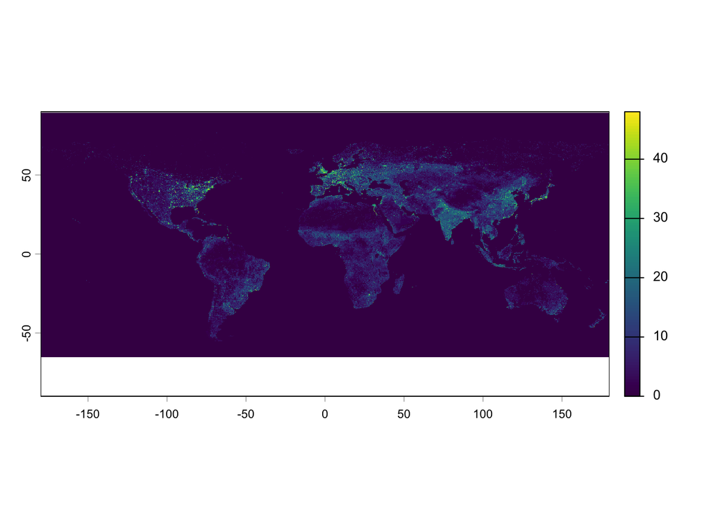

## Extract environmental information

We show two ways how we can use the spatial grids to annotate individual trait summaries with the environment.

### A: intersect the grid centroid coordinate with the spatial layer of interest.

Mind, when the spatial resolution of the spatial layer is much higher than the grid resolution (100km or 10km), using the centroid for annotation can be misleading. (if the layer was downlaoded with the geodata package please replace zcol “HFP2009” with “wildareas.v3.2009.human.footprint”)

```r
pts <- vect(centroids, crs = "EPSG:4326")
values <- terra::extract(hfi, pts, ID = FALSE, bind = TRUE)
values_sf <- sf::st_as_sf(values)

intersect_cells_100_centroidHFI <- intersect_cells_100 |>
  left_join(st_drop_geometry(values_sf), by = c("seqnum" = "grid.id.100km"))

mapview(intersect_cells_100_centroidHFI, map.types = c("OpenStreetMap.DE"),
        zcol = "wildareas.v3.2009.human.footprint",
        col.regions = colorRampPalette(rev(brewer.pal(11, "RdYlBu"))))
```

[interactive chart not shown]

### B: calculating the mean HFI of all values intersecting with the spatial grid cell.

This way - uncertainty about where the animal was located within the diffused grid cell is accounted for

```r
hfi_mean <- terra::extract(hfi, terra::vect(intersect_cells_100), fun = mean, na.rm = TRUE)

intersect_cells_100_meanHFI <- intersect_cells_100 |>
  mutate(hfi_mean = hfi_mean[, 2])

mapview(intersect_cells_100_meanHFI, zcol = "hfi_mean",
        map.types = "OpenStreetMap.DE", col.regions = colorRampPalette(rev(brewer.pal(11, "RdYlBu"))))
```

[interactive chart not shown]

We recommend calculating the mean value of the environmental layer within each grid cell instead of using the raw values at the centroid coordinate, whenever the spatial resolution of the environmental layer is finer than the grid cell size.

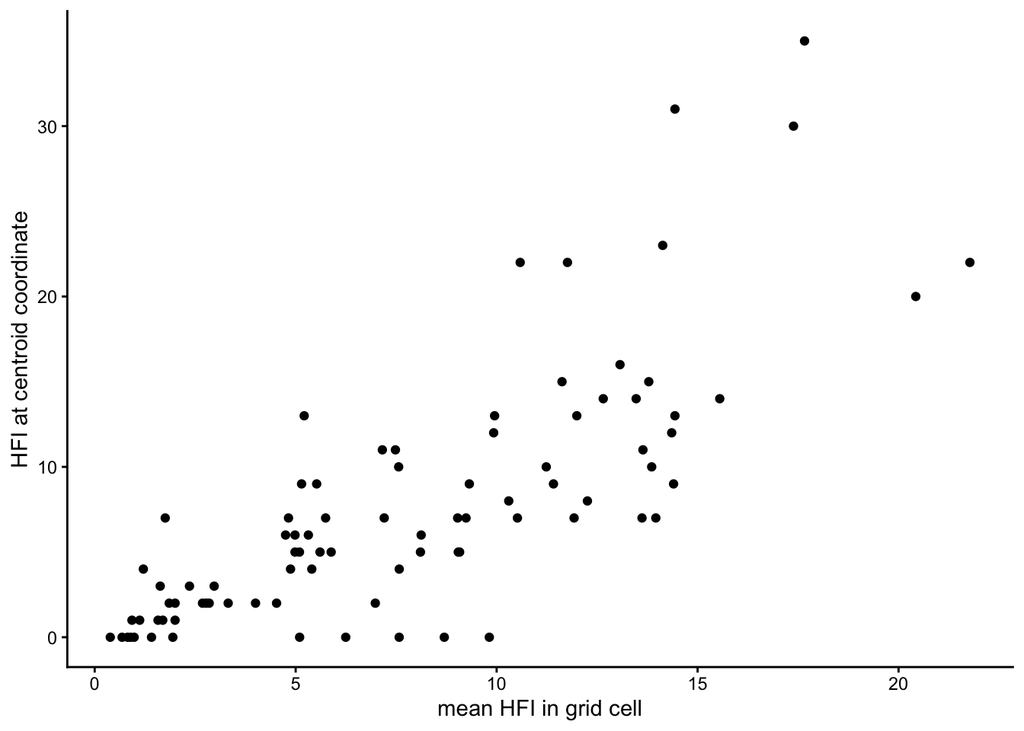

# **Monthly summary**

The monthly summary table contains one row per individual and month. Finer temporal traits (1h & 24h displacement, max24h displacement, 24h range size, 24h intensity of use and diurnality index) are summarised for each month. Monthly traits (monthly maximum displacement, range size and intensity of use) appear as repeated trait measures. Annual traits are not listed - please refer to the individual summary or the repeated within individual trait measures.

```r
mt_month <- readRDS("MoveTrait.v0.1_monthly.sum_20260807.rds")
```

The monthly summaries of traits are spatially referenced with all grid cells (grid.id.100km and grid.id.10km columns) that were occupied during the given month by the individual.

For this section we will use a range resident fisher as an example.

The data are from “LaPoint S. 2026. Data from: Study "Carnivore movements near Black Rock Forest New York". Movebank Data Repository. https://doi.org/10.5441/001/1.652  
These data are described in  
Oliver RY, Yanco SW, Ellis-Soto D, Jesmer BR, Cohen J, Gao S, Patchett R, Avgar T, Bildstein K, Bakner NW, et al. 2026. Interacting effects of human presence and landscape modification on birds and mammals. Science. https://doi.org/10.1126/science.adq3396  
LaPoint et al. in progress”

```r
focal_individual <- "2705708446"
```

|  | study_id | individual_id | species | common_name | month | year | grid.id.100km | grid.id.10km | d1h.mean | d24h.mean | dmax24h.mean | mcp24h.mean | dmax1m | mcp1m | iou1m |
| --- | --- | --- | --- | --- | --- | --- | --- | --- | --- | --- | --- | --- | --- | --- | --- |
| 2674 | 1088836380 | 2705708446 | Martes pennanti | fisher | 2 | 2023 | 5425 | 434454 | 608.1715 | 6153.639 | 5164.176 | NA | NA | NA | NA |
| 2675 | 1088836380 | 2705708446 | Martes pennanti | fisher | 3 | 2023 | 5425 | 434454;435183;434453;435182 | 239.6489 | 1537.244 | 2398.603 | 1653835.8 | 13664.714 | 40879565 | 6.97248 |
| 2676 | 1088836380 | 2705708446 | Martes pennanti | fisher | 4 | 2023 | 5425 | 435183 | 157.0405 | 886.432 | 1293.078 | 458243.3 | 2752.014 | 1697075 | 19.05252 |

The information, which cells were occupied in which months need to be unpacked from wide to long format, here exemplary done for grid.id.10km. The same procedure applies to the 100km grid.

```r
monthly_cells_10 <- mt_month |>
  filter(individual_id == focal_individual) |>
  separate_rows(grid.id.10km, sep = ";") %>%
  mutate(grid.id.10km = as.numeric(grid.id.10km),
         month = str_pad(month, width = 2, pad = "0"),
         year_month = as.factor(paste(year,month,sep="_")))
```

The long format data column can then be used to identify which cells were occupied.

```r
intersect_cells_10 <- dgcellstogrid(dggs.10, monthly_cells_10$grid.id.10km)
intersect_cells_10 <-
  merge(intersect_cells_10,
        monthly_cells_10[,c("grid.id.10km","year_month")],
        by.x="seqnum",by.y="grid.id.10km")
```

We can now visualize where the individual had been in specific months.

```r
mapview(intersect_cells_10, map.types = c("OpenStreetMap.DE"), zcol = "year_month")
```

[interactive chart not shown]

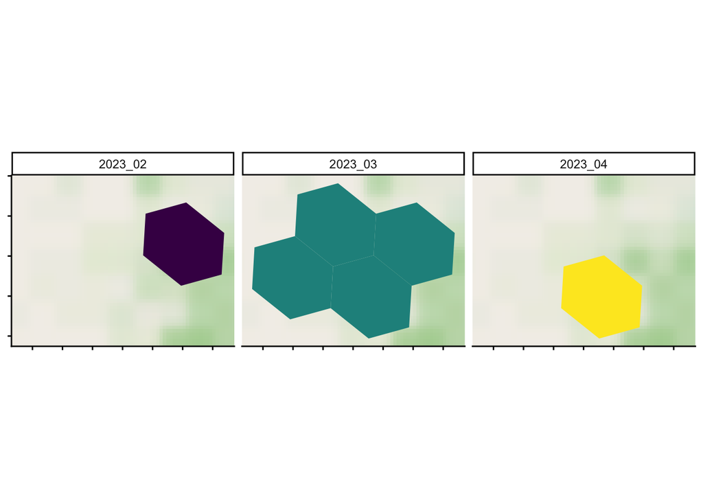

```r
ggplot() +
    annotation_map_tile(type = "osm", zoom = 5, quiet = TRUE) +
    geom_sf(data = intersect_cells_10, aes(fill = year_month), colour = NA) +
    scale_fill_viridis_d() +
    theme_classic() +
    facet_wrap(~year_month) +
    theme(axis.text = element_blank())+
    theme(legend.position = "none")
```

## Extract environmental information

Trait summaries can be annotated with environmental conditions using time information (i.e. month and year) and monthly specific spatial grid cells.

```r
hfi_mean <- terra::extract(hfi, terra::vect(intersect_cells_10), fun = mean, na.rm = TRUE)

intersect_cells_10_meanHFI <- intersect_cells_10 |>
  mutate(hfi_mean_cell = hfi_mean[, 2]) |>
  group_by(year_month) |>
  mutate(mean_hfi_month = mean(hfi_mean_cell))

mapview(intersect_cells_10_meanHFI[intersect_cells_10_meanHFI$year_month %in% "2023_03",],
        zcol = "hfi_mean_cell",
        map.types = "OpenStreetMap.DE",
        col.regions = colorRampPalette(rev(brewer.pal(11, "RdYlBu"))),
        layer.name = "Mean HFI")
```

[interactive chart not shown]

# **Within Individual repeated trait measures**

```r
mt_wind <- readRDS("MoveTrait.v0.1_withinindividual_20260807.rds")
```

The third level of the database provides repeated individual trait measures. For each individual and every trait we provide the underlying repeated trait measures as a list of nested dataframes in columns 12 - 23

```r
names(mt_wind)
```

```
##  [1] "study_id"                    "individual_id"
##  [3] "individual_local_identifier" "species"
##  [5] "common_name"                 "class"
##  [7] "movement.mode"               "sex"
##  [9] "animal_mass"                 "animal_life_stage"
## [11] "source"                      "d1h"
## [13] "d24h"                        "dmax24h"
## [15] "dmax1m"                      "dmax12m"
## [17] "mcp24h"                      "mcp1m"
## [19] "mcp12m"                      "iou24h"
## [21] "iou1m"                       "iou12m"
## [23] "di"                          "median_timelag_mins"
## [25] "tracking_duration_days"      "tracking_start_date"
## [27] "tracking_end_date"           "contact_person_name"
## [29] "license_type"                "citation"
```

```r
class(mt_wind[,12])
```

```
## [1] "list"
```

For this section we will use a range resident lion as an example.

## Maximum displacement - grid cells to end points

```r
focal_individual <- "3791479362"
example.dmax24h <- mt_wind[mt_wind$individual_id == focal_individual, "dmax24h"][[1]]
```

For this individual we have 487 maximum daily displacement records, we select one for demonstrative purposed

```r
nrow(example.dmax24h)
```

```
## [1] 487
```

```r
example.dmax24h <- example.dmax24h[380,]
head(example.dmax24h)
```

```
## # A tibble: 1 × 8
##   ymd       dmax24h lon_start lat_start lon_end lat_end grid.id.10km grid.id.1km
##   <chr>       <dbl>     <dbl>     <dbl>   <dbl>   <dbl> <chr>        <chr>
## 1 2011-11-…  13834.      23.3     -21.3    23.4   -21.3 1504285;150… 121827858;…
```

For open access data, individual trait measures contains the latitude and longitude of the start and end points of the longest displacement segment. For closed access data it contains the identity of the two grid cell that contain the start and endpoints coordinate of the segment, at either 10km, or 10km and 1km resolution, depending on the data owner’s sharing selection.

We here visualize the true endpoints and the associated grid cells at 10km and 1km for one segment of maximum daily displacement.

```r
# start and endpoint grid cells at 1km
cells_1 <- example.dmax24h |>
  dplyr::select(grid.id.1km) |>
  tidyr::separate_longer_delim(grid.id.1km, delim = ";") |>
  mutate(grid.id.1km = as.integer(grid.id.1km))
intersect_cells_1 <- dgcellstogrid(dggs.1, unique(cells_1$grid.id.1km))

# start and endpoint grid cells at 10km
cells_10 <- example.dmax24h |>
  dplyr::select(grid.id.10km) |>
  tidyr::separate_longer_delim(grid.id.10km, delim = ";") |>
  mutate(grid.id.10km = as.integer(grid.id.10km))
intersect_cells_10 <- dgcellstogrid(dggs.10, unique(cells_10$grid.id.10km))

# start and end coordinates as sf object
start_pt <- example.dmax24h |>
  st_as_sf(coords = c("lon_start", "lat_start"), crs = 4326)
end_pt <- example.dmax24h |>
  st_as_sf(coords = c("lon_end", "lat_end"), crs = 4326)

# daily maximum displacement as segment
segment <- c(st_geometry(start_pt), st_geometry(end_pt)) |>
  st_combine() |>
  st_cast("LINESTRING") |>
  st_as_sf()

# visualize
mapview(intersect_cells_10, map.types = c("OpenStreetMap.DE"), legend = FALSE,
        col.regions = "transparent", alpha.regions = 0, color = "steelblue", lwd = 2,
        layer.name = "10 km grid size") +
mapview(intersect_cells_1, map.types = c("OpenStreetMap.DE"), legend = FALSE,
        col.regions = "transparent", alpha.regions = 0, color = "darkorange", lwd = 1,
        layer.name = "1 km grid size") +
  mapview(start_pt, col.regions = "green",     cex = 8, layer.name = "Start") +
  mapview(end_pt,   col.regions = "red",       cex = 8, layer.name = "End") +
  mapview(segment,      color = "black",  lwd = 3, layer.name = "Dmax24h")
```

[interactive chart not shown]

Environmental context (e.g., HFI) can be extracted and averaged within the grid cells intersecting the endpoints.

```r
meanHFI <- terra::extract(hfi,
  terra::vect(sf::st_transform(intersect_cells_10, terra::crs(hfi))),
  fun = mean, na.rm = TRUE, ID = FALSE)
intersect_cells_10$wildareas.v3.2009.human.footprint <- meanHFI[, 1]
head(intersect_cells_10)
```

```
## Simple feature collection with 2 features and 2 fields
## Geometry type: POLYGON
## Dimension:     XY
## Bounding box:  xmin: 23.18217 ymin: -21.38546 xmax: 23.43544 ymax: -21.19204
## Geodetic CRS:  WGS 84
##    seqnum                       geometry wildareas.v3.2009.human.footprint
## 1 1504285 POLYGON ((23.24742 -21.3854...                                 0
## 2 1505016 POLYGON ((23.38848 -21.2989...                                 0
```

## Home range - from vertices to home range polygons

Next we demonstrate how home ranges are annotated and how grid cells can be used to reverse engineer the are where the home range was roughly placed.

Range sizes are calculated as 95% Minimum Convex Polygon of all GPS locations in a given time frame (e.g., within one day, month, or year).

For open access data, range sizes are annotated with vertex coordinates which can be directly transformed back into the MCP polygon. Alternatively, these vertex coordinates are diffused at 1 or 10 km allowing to reproduce the home range at a courser scale.

```r
all_mcp1m <- mt_wind[mt_wind$individual_id == focal_individual, "mcp1m"][[1]]
head(all_mcp1m)
```

```
## # A tibble: 6 × 8
##   id      month year_month   area x_vertices y_vertices grid.id.10km grid.id.1km
##   <chr>   <dbl> <chr>       <dbl> <chr>      <chr>      <chr>        <chr>
## 1 379147…    10 2010_10    3.48e7 23.261966… -21.29664… 1503555;150… 121775360;…
## 2 379147…    11 2010_11    1.91e8 23.290436… -21.31832… 1503557;150… 121795046;…
## 3 379147…    12 2010_12    1.84e8 23.331748… -21.24865… 1503556;150… 121749117;…
## 4 379147…     1 2011_1     1.42e8 23.293284… -21.19080… 1503557;150… 121775374;…
## 5 379147…    10 2011_10    7.16e7 23.241883… -21.33856… 1503555;150… 121742552;…
## 6 379147…    11 2011_11    1.34e8 23.28737;… -21.27242… 1503555;150… 121781923;…
```

```r
example.mcp1m <- all_mcp1m[1,]
```

We select a single monthly home range for demonstration purposes.

### Observation level data

Function to reproduce home ranges for individuals with observation level data.

```r
vertices_to_polygon <- function(x_vertices, y_vertices) {
  x <- as.numeric(str_split(x_vertices, ";", simplify = TRUE))
  y <- as.numeric(str_split(y_vertices, ";", simplify = TRUE))

  coords <- cbind(x, y)
  coords <- coords[complete.cases(coords), , drop = FALSE]

  if (!all(coords[1, ] == coords[nrow(coords), ])) {
    coords <- rbind(coords, coords[1, , drop = FALSE])
  }

  st_polygon(list(coords))
}
```

```r
mcp_observation <- example.mcp1m %>%
  mutate(
    geometry = map2(x_vertices, y_vertices, vertices_to_polygon),
    month = as.factor(month)) %>%
  st_as_sf(sf_column_name = "geometry", crs = 4326)
```

```r
mapview(mcp_observation,
        col.regions = colorRampPalette(rev(brewer.pal(11, "RdYlBu"))))
```

[interactive chart not shown]

### 1. unpack the grid cell vertices of the range. Vertices are stored in column “grid.id.10km” or “grid.id.1km” into long format.

```r
cells_long <- example.mcp1m %>%
  dplyr::select(id, month, year_month, area, grid.id.1km)  |>
  separate_rows(grid.id.1km, sep = ";") |>
  filter(!is.na(grid.id.1km), grid.id.1km != "") |>
  mutate(grid.id.1km = as.integer(grid.id.1km),
         year_month = as.factor(year_month))
```

```
## # A tibble: 5 × 5
##   id                 month year_month      area grid.id.1km
##   <chr>              <dbl> <fct>          <dbl>       <int>
## 1 3791479362_2010_10    10 2010_10    34831134.   121775360
## 2 3791479362_2010_10    10 2010_10    34831134.   121781916
## 3 3791479362_2010_10    10 2010_10    34831134.   121795048
## 4 3791479362_2010_10    10 2010_10    34831134.   121808168
## 5 3791479362_2010_10    10 2010_10    34831134.   121827859
```

```r
grid_sf <- dgcellstogrid(dggs.1, cells_long$grid.id.1km) |>
  left_join(cells_long,year_month, by = c("seqnum" = "grid.id.1km"))

mapview(grid_sf,
        col.regions = colorRampPalette(rev(brewer.pal(11, "RdYlBu"))),
        layer.name = "Home range vertices")
```

[interactive chart not shown]

### 3. recreate the MCP based on the grid cells

```r
mcp_1km <- grid_sf %>%
  group_by(year_month) %>%
  summarise(geometry = st_union(geometry), .groups = "drop") |>
  mutate(geometry = st_convex_hull(geometry))
```

This individual’s data were open access and we hence can show the vertices of the calcualted MCP - here in orange. The vertices fall into three adjacent 10km grid cells. For closed access data, we do not know where the observed vertices were placed but we can reconstruct an area within which the home range falls by drawing a polygon around the annotated grid cells.

[interactive chart not shown]

For 10 km grid cells this recreated home range is obviously much less precise.

[interactive chart not shown]

### 4. Annotate ranges with environmental covariates

The polygons created either from observation level coordinates or from grid cells can then be used to annotate traits with environmental layers.

Here, for example in bulk for all monthly home ranges observed for this lion.

```r
head(all_mcp1m)
```

```
## # A tibble: 6 × 8
##   id      month year_month   area x_vertices y_vertices grid.id.10km grid.id.1km
##   <chr>   <dbl> <chr>       <dbl> <chr>      <chr>      <chr>        <chr>
## 1 379147…    10 2010_10    3.48e7 23.261966… -21.29664… 1503555;150… 121775360;…
## 2 379147…    11 2010_11    1.91e8 23.290436… -21.31832… 1503557;150… 121795046;…
## 3 379147…    12 2010_12    1.84e8 23.331748… -21.24865… 1503556;150… 121749117;…
## 4 379147…     1 2011_1     1.42e8 23.293284… -21.19080… 1503557;150… 121775374;…
## 5 379147…    10 2011_10    7.16e7 23.241883… -21.33856… 1503555;150… 121742552;…
## 6 379147…    11 2011_11    1.34e8 23.28737;… -21.27242… 1503555;150… 121781923;…
```

```r
# Reconstruct monthly home range polygons for all rows
all_mcp1m_sf <- all_mcp1m |>
  mutate(
    geometry = map2(x_vertices, y_vertices, vertices_to_polygon),
    month    = as.factor(month)
  ) |>
  st_as_sf(sf_column_name = "geometry", crs = 4326)

# Extract mean HFI within each monthly polygon
hfi_extracted <- terra::extract(hfi, terra::vect(all_mcp1m_sf), fun = mean, na.rm = TRUE)

# Join mean HFI back to all_mcp1m
all_mcp1m <- all_mcp1m |>
  mutate(hfi.mean = hfi_extracted[, 2])

head(all_mcp1m)
```

```
## # A tibble: 6 × 9
##   id      month year_month   area x_vertices y_vertices grid.id.10km grid.id.1km
##   <chr>   <dbl> <chr>       <dbl> <chr>      <chr>      <chr>        <chr>
## 1 379147…    10 2010_10    3.48e7 23.261966… -21.29664… 1503555;150… 121775360;…
## 2 379147…    11 2010_11    1.91e8 23.290436… -21.31832… 1503557;150… 121795046;…
## 3 379147…    12 2010_12    1.84e8 23.331748… -21.24865… 1503556;150… 121749117;…
## 4 379147…     1 2011_1     1.42e8 23.293284… -21.19080… 1503557;150… 121775374;…
## 5 379147…    10 2011_10    7.16e7 23.241883… -21.33856… 1503555;150… 121742552;…
## 6 379147…    11 2011_11    1.34e8 23.28737;… -21.27242… 1503555;150… 121781923;…
## # ℹ 1 more variable: hfi.mean <dbl>
```